# Lab 07 - Smokers in Whickham

Simpson’s paradox

Max Asmar

## Introduction

A study conducted in Whickham, England recorded participants’ age, smoking status at baseline, and then 20 years later recorded their health outcome. In this lab we analyze the relationships between these variables, first two at a time, and then controlling for a third variable.

**You might be surprised by what you find!** This lab demonstrates an important statistical phenomenon called **Simpson’s paradox**, where a trend that appears in different groups of data disappears or reverses when the groups are combined. Understanding this paradox is crucial for correctly interpreting data and avoiding misleading conclusions.

**Estimated time:** 60-90 minutes

## Learning Goals

By the end of this lab, you will be able to:

- Distinguish between observational studies and experiments
- Visualize relationships between categorical variables
- Calculate and interpret conditional probabilities
- Create categorical variables from continuous variables using `case_when()`
- Use faceting to explore three-way relationships
- Identify and explain Simpson’s paradox
- Understand the role of confounding variables

## Prerequisites

Before you begin, make sure you have:

- ✅ Completed Labs 01-06
- ✅ Watched lectures on categorical data and conditional probability
- ✅ Understand bar plots and mosaic plots
- ✅ Forked the lab-instructions repository

# Getting Started

Navigate to your forked `lab-instructions` repository in JupyterHub, open the `Lab07` folder, and open the R Markdown document `lab-07.Rmd`.

## Verify Your Setup

Before proceeding:

Step 1. Open `lab-07.Rmd` in RStudio

Step 2. Check that the Git pane shows YOUR username (not the course organization)

Step 3. Click **Knit** to make sure the document compiles

## Warm Up

Before we introduce the data, let’s warm up with some simple exercises.

**Step 1:** Update the YAML, changing the author name to your name.

**Step 2:** Knit the document.

**Step 3:** Commit your changes with message “Updated author name”.

**Step 4:** Push to GitHub and verify the changes are visible in your repo.

🧶 ✅ ⬆️ **Knit, commit with message “Completed warm up”, and push your changes.**

# Completed Warm Up

## Packages

We’ll use the **tidyverse** package for much of the data wrangling and visualisation and the data lives in the **mosaicData** package. These packages are already installed for you. You can load them by running the following in your Console:

```r
library(tidyverse)
library(mosaicData)
```

## Data

The dataset we’ll use is called `Whickham` from the **mosaicData** package. You can find out more about the dataset by inspecting its documentation, which you can access by running `?Whickham` in the Console or using the Help menu in RStudio to search for `Whickham`.

**✓ Checkpoint:** Run `glimpse(Whickham)` in your Console to verify the data loaded correctly.

# glimpse(Whickham) worked correctly

# Exercises

## Understanding the Study

## Exercise 1

What type of study do you think these data come from: observational or experiment? Why?

**Definitions to help you decide:**

- **Observational study:** Researchers observe and measure variables but don’t intervene or assign treatments
- **Experiment:** Researchers actively assign treatments/interventions to participants

**Your answer:**

This is an observational study because the researchers are tracking the age and mortality outcomes across smokers and non-smokers. The researchers are not treating the smokers with any medication and are treating it as a closed system.

## Exercise 2

How many observations are in this dataset? What does each observation represent?

**Hint:** Use inline code with `nrow()` to report the number of observations.

**Your answer:**

The dataset has 1314 observations. Each observation represents a woman who is a smoker or non- smoker, and her age and mortality status after 20 years.

🧶 ✅ ⬆️ **Knit, commit with message “Completed Exercises 1-2”, and push your changes.**

## Exploring the Variables

## Exercise 3

How many variables are in this dataset? What type of variable is each? Display each variable using an appropriate visualization.

**Part A: Count and classify the variables**

Run `glimpse(Whickham)` in your Console to see the variables.

**Number of variables:** There are 3 variables in the dataset.

**Variable types:**

| Variable | Type (categorical/numerical) | More specific type |
| --- | --- | --- |
| outcome | categorical | nominal |
| smoker | categorical | nominal |
| age | numerical | continuous (whole numbers) |

**Part B: Create visualizations**

Create appropriate visualizations for each variable.

**For categorical variables (outcome and smoker):**

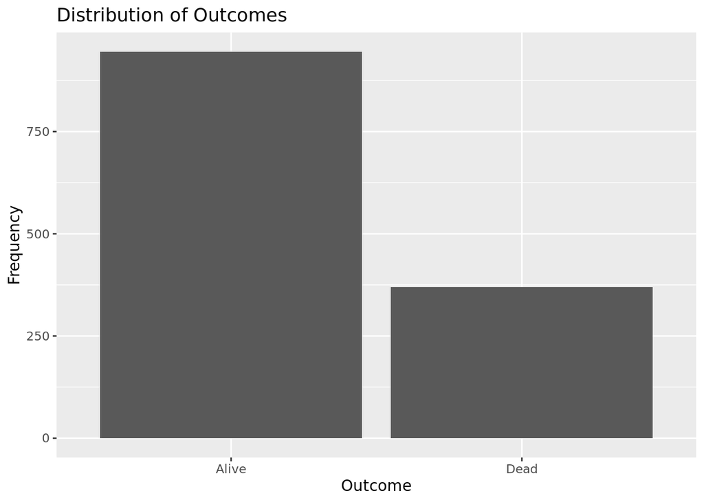

```r
# Remember to change eval=FALSE to eval=TRUE!

# Outcome variable
ggplot(data = Whickham, aes(x = outcome)) +
  geom_bar() +
  labs(
    title = "Distribution of Outcomes",
    x = "Outcome",
    y = "Frequency"
  )
```

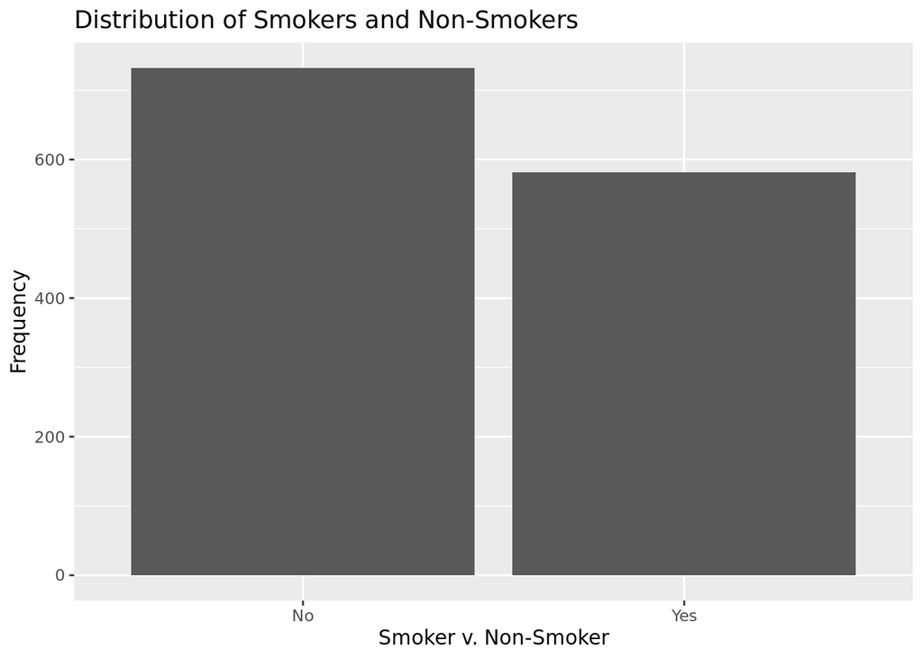

```r
# Smoker variable
ggplot(data = Whickham, aes(x = smoker)) +
  geom_bar() +
  labs(
    title = "Distribution of Smokers and Non-Smokers",
    x = "Smoker v. Non-Smoker",
    y = "Frequency"
  )
```

**For numerical variable (age):**

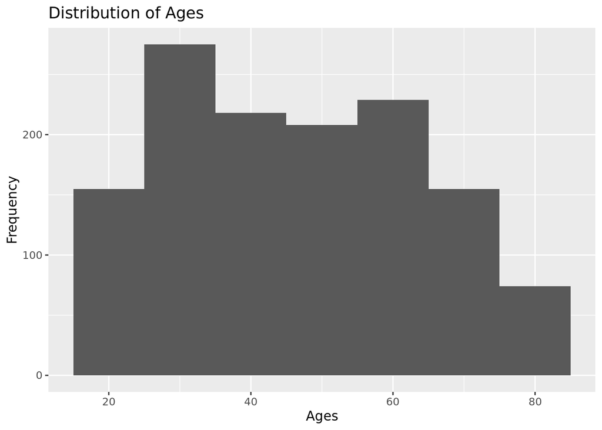

```r
# Remember to change eval=FALSE to eval=TRUE!
ggplot(data = Whickham, aes(x = age)) +
  geom_histogram(binwidth = 10) +
  labs(
    title = "Distribution of Ages",
    x = "Ages",
    y = "Frequency"
  )
```

**Hint:** Try a binwidth of 5 or 10 for age.

## Making Predictions

## Exercise 4

What would you expect the relationship between smoking status and health outcome to be?

**Think about it:** If we compare smokers to non-smokers after 20 years, what difference would you expect to see in their health outcomes?

**Your prediction:**

I would expect that smokers would have worse health outcomes than non-smokers. I expect that smokers would be affected by lung damage and therefore would have higher mortality rates than non-smokers.

🧶 ✅ ⬆️ **Knit, commit with message “Completed Exercises 3-4”, and push your changes.**

## Examining the Relationship

## Exercise 5

Create a visualization depicting the relationship between smoking status and health outcome. Briefly describe the relationship, and evaluate whether this meets your expectations. Additionally, calculate the relevant conditional probabilities to help your narrative.

**Part A: Create a visualization**

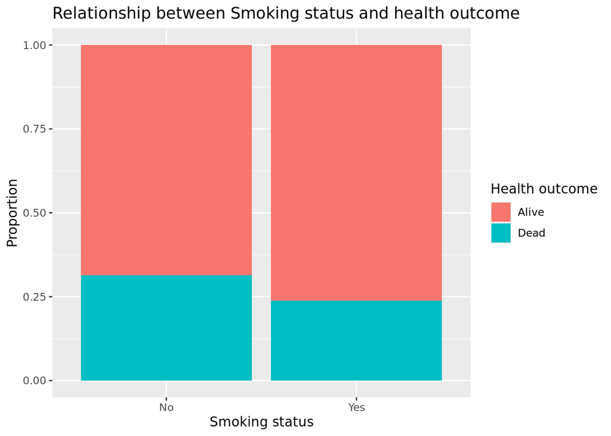

```r
# Remember to change eval=FALSE to eval=TRUE!
ggplot(data = Whickham, aes(x = smoker, fill = outcome)) +
  geom_bar(position = "fill") +
  labs(
    title = "Relationship between Smoking status and health outcome",
    x = "Smoking status",
    y = "Proportion",
    fill = "Health outcome"
  )
```

**Hints:**

- Put `smoker` on the x-axis and fill by `outcome`
- Try `position = "fill"` to show proportions, or `position = "dodge"` to show counts side-by-side

**Part B: Calculate counts**

Here is some code to get you started:

```r
Whickham %>%
  count(smoker, outcome)
```

```
##   smoker outcome   n
## 1     No   Alive 502
## 2     No    Dead 230
## 3    Yes   Alive 443
## 4    Yes    Dead 139
```

**What this shows:** The number of people in each combination of smoking status and outcome.

**Part C: Calculate conditional probabilities**

Calculate the probability of being alive given smoking status.

```r
# Remember to change eval=FALSE to eval=TRUE!
Whickham %>%
  count(smoker, outcome) %>%
  group_by(smoker) %>%
  mutate(proportion = n / sum(n))
```

```
## # A tibble: 4 × 4
## # Groups:   smoker [2]
##   smoker outcome     n proportion
##   <fct>  <fct>   <int>      <dbl>
## 1 No     Alive     502      0.686
## 2 No     Dead      230      0.314
## 3 Yes    Alive     443      0.761
## 4 Yes    Dead      139      0.239
```

**Interpret the results:**

- Proportion of smokers who are alive after 20 years: 0.761
- Proportion of non-smokers who are alive after 20 years: 0.686

**Does this meet your expectations? What do you notice?**

This does not match my expectations because I would expect non-smokers to have higher survival rates after 20 years because of the health concerns associated with smoking such as cancer and cardiovascular disease. I wonder why this is the case.

🧶 ✅ ⬆️ **Knit, commit with message “Completed Exercise 5”, and push your changes.**

## Adding a Third Variable

## Exercise 6

Create a new variable called `age_cat` using the following scheme:

- age ≤ 44 → “18-44”
- age > 44 and age ≤ 64 → “45-64”
- age > 64 → “65+”

**Use `case_when()` to create the categorical variable:**

```r
# Remember to change eval=FALSE to eval=TRUE!
Whickham <- Whickham %>%
  mutate(age_cat = case_when(
    age <= 44 ~ "18-44",
    age > 44 & age <= 64 ~ "45-64",
    age > 64 ~ "65+"
  ))
```

**What this code does:**

- Takes the `Whickham` dataset
- Uses `mutate()` to create a new variable called `age_cat`
- `case_when()` checks each condition in order and assigns the corresponding category
- Saves the result back to `Whickham` using `<-`

**Verify it worked:**

```r
# Remember to change eval=FALSE to eval=TRUE!
Whickham %>%
  count(age_cat)
```

```
##   age_cat   n
## 1   18-44 624
## 2   45-64 447
## 3     65+ 243
```

**How many people are in each age category?**

- 18-44: 624 people
- 45-64: 447 people
- 65+: 243 people

## The Big Reveal: Simpson’s Paradox

## Exercise 7

Re-create the visualization depicting the relationship between smoking status and health outcome, faceted by `age_cat`. What changed? What might explain this change?

**Part A: Create the faceted visualization**

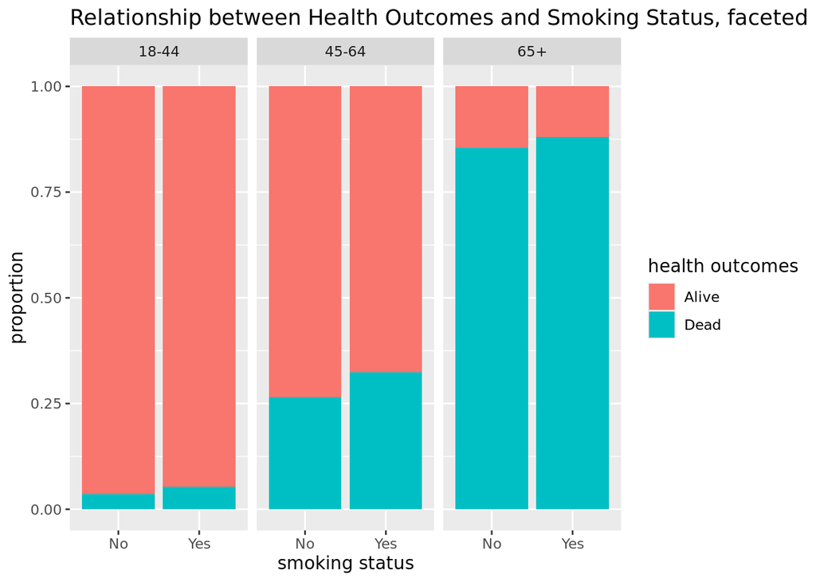

```r
# Remember to change eval=FALSE to eval=TRUE!
ggplot(data = Whickham, aes(x = smoker, fill = outcome)) +
  geom_bar(position = "fill") +
  facet_wrap(~age_cat) +
  labs(
    title = "Relationship between Health Outcomes and Smoking Status, faceted by age group",
    x = "smoking status",
    y = "proportion",
    fill = "health outcomes"
  )
```

Now, across all three age groups (facets), I see that non-smokers tend to have a higher survival rate than smokers do. This aligns with my initial hypothesis that non-smokers would have better health outcomes than smokers. I think Simpson’s paradox might explain this change, and the change was caused by uneven sample sizes and confounding variables.

**Hint:** Use the same aesthetics as Exercise 5, but add `facet_wrap(~age_cat)`

**Part B: Examine the three-way contingency table**

Extend the contingency table from earlier by breaking it down by age category:

```r
# Remember to change eval=FALSE to eval=TRUE!
Whickham %>%
  count(smoker, age_cat, outcome)
```

```
##    smoker age_cat outcome   n
## 1      No   18-44   Alive 327
## 2      No   18-44    Dead  12
## 3      No   45-64   Alive 147
## 4      No   45-64    Dead  53
## 5      No     65+   Alive  28
## 6      No     65+    Dead 165
## 7     Yes   18-44   Alive 270
## 8     Yes   18-44    Dead  15
## 9     Yes   45-64   Alive 167
## 10    Yes   45-64    Dead  80
## 11    Yes     65+   Alive   6
## 12    Yes     65+    Dead  44
```

**Calculate proportions within each age group:**

```r
# Remember to change eval=FALSE to eval=TRUE!
Whickham %>%
  count(smoker, age_cat, outcome) %>%
  group_by(smoker, age_cat) %>%
  mutate(proportion = n / sum(n))
```

```
## # A tibble: 12 × 5
## # Groups:   smoker, age_cat [6]
##    smoker age_cat outcome     n proportion
##    <fct>  <chr>   <fct>   <int>      <dbl>
##  1 No     18-44   Alive     327     0.965
##  2 No     18-44   Dead       12     0.0354
##  3 No     45-64   Alive     147     0.735
##  4 No     45-64   Dead       53     0.265
##  5 No     65+     Alive      28     0.145
##  6 No     65+     Dead      165     0.855
##  7 Yes    18-44   Alive     270     0.947
##  8 Yes    18-44   Dead       15     0.0526
##  9 Yes    45-64   Alive     167     0.676
## 10 Yes    45-64   Dead       80     0.324
## 11 Yes    65+     Alive       6     0.12
## 12 Yes    65+     Dead       44     0.88
```

**Part C: Interpret the results**

**What changed when you added age_cat?**

When I added age_cat, the proportions of non-smokers alive after 20 years became higher than the percentage of smokers alive after 20 years for all age groups. For example, using the conditional probability table, I found that 96.5% of non-smokers were alive after 20 years while only 94.7% of smokers were alive after 20 years for age ranges 18-44.

**Compare the relationship between smoking and outcome:**

Smoking is associated with higher mortality rates after 20 years. There is a positive relationship between the two variables.

**Overall (from Exercise 5):** Smokers appeared to have higher survival rates.

**Within each age group (from Exercise 7):** Smokers appear to have lower survival rates.

**What might explain this change?**

Consider:

- Which age groups have more smokers?
- Which age groups have higher survival rates overall?
- How might age affect both smoking status and survival?

**Your explanation:**

People from ages 18-44 had the greatest number of smokers while people over and at the age 65 had the fewest number of smokers. To be more specific, the group 18-44 had 285 smokers, while the age group 65+ had 50 smokers. Also, using the contingency table, people in the age group 18-44 had higher survival rates overall, whether they smoked or did not smoke, compared to other groups. I think that as our bodies stop growing, we feel the effects of smoking more deeply, causing higher mortality rates in 20 years for people in older age groups. Statistically speaking, since more of the smokers were concentrated in the age group 18-44, which had higher survival rates, this caused the overall comparison between smokers and non-smokers to be inadequate for our level of analysis.

🧶 ✅ ⬆️ **Knit, commit with message “Completed Exercises 6-7”, and push your changes.**

## Understanding Simpson’s Paradox

**What you just discovered is called Simpson’s Paradox!**

Simpson’s paradox was first described by Edward Simpson in 1951, though similar observations were made earlier by others.

**Simpson’s Paradox** occurs when a trend appears in several groups of data but disappears or reverses when the groups are combined. In this case:

- **Overall:** Smokers appeared to have *better* survival than non-smokers
- **Within each age group:** Smokers had *worse* survival than non-smokers

**Why did this happen?**

The key is that **age is a confounding variable**:

- **Age affects survival:** Younger people are more likely to survive 20 years than older people (regardless of smoking status)
- **Age affects smoking status:** In this study, smokers were younger on average than non-smokers
- **The age difference masks the true effect of smoking:** The overall comparison was unfair because it compared a younger group of smokers to an older group of non-smokers

**The lesson:** When exploring relationships between variables, it’s crucial to consider potential confounding variables. What appears to be true overall may not be true when you look within subgroups, and vice versa.

**Real-world implications:**

- Medical studies must control for confounding variables like age, sex, and health status
- Policy decisions based on aggregated data can be misleading if important subgroups differ
- Always ask: “What other variables might be affecting this relationship?”

**Reflection question:** Can you think of other situations where Simpson’s paradox might occur? What confounding variables should researchers watch out for in studies about health, education, or economics?

## Common Errors and Troubleshooting

**Visualization errors:**

- **Bar plot shows counts instead of proportions** → Use `position = "fill"` in `geom_bar()`
- **Can’t see both outcome categories** → Make sure `fill = outcome` is inside `aes()`
- **Facets not appearing** → Check spelling of `age_cat` in `facet_wrap()`
- **Error: “object ‘age_cat’ not found”** → Make sure you ran Exercise 6 and saved the result back to `Whickham`

**case_when() errors:**

- **Some ages showing as NA** → Make sure your conditions cover all possible ages (use `TRUE ~ "Other"` as a catch-all if needed)
- **Categories in wrong order** → `case_when()` evaluates in order, so put more specific conditions first
- **Error: “could not find function ‘case_when’”** → Load tidyverse: `library(tidyverse)`

**Conditional probability errors:**

- **Proportions don’t add up to 1** → Make sure you’re grouping by the right variable(s)
- **Getting counts instead of proportions** → Divide n by sum(n): `mutate(proportion = n / sum(n))`
- **Proportions sum to wrong value** → Check your `group_by()` - you want proportions within each smoking group

**Data errors:**

- **Error: “object ‘Whickham’ not found”** → Load the mosaicData package: `library(mosaicData)`
- **Changes not saving** → Remember to use `<-` to save mutated data back to `Whickham`

**General issues:**

- **Code chunk not running** → Make sure you changed `eval=FALSE` to `eval=TRUE`
- **Inline code not working** → Use inline code syntax in narrative text (not in code chunks)

**To submit to Canvas:**

Step 1. In RStudio, click the **Knit** dropdown menu (next to the Knit button)

Step 2. Select **Knit to tufte_handout** to generate a PDF

Step 3. Download the PDF file from the Files pane

Step 4. Upload the PDF to Canvas

**✓ Final Checkpoint:** Visit your GitHub repo one more time to confirm all your work is there. We will grade what we see in your repo on GitHub!